# Sovereign Default: Eaton-Gersovitz / Arellano (2008)

David Evans

2026-03-16

# Introduction

## From Domestic to International

### Where We’ve Been

- **McCall (1970)**: an unemployed worker searches for a job — solve for a reservation wage
- **Rust (1987)**: a bus superintendent decides when to replace engines — estimate structural parameters
- **Kydland & Prescott (1982)**: a representative agent in a macroeconomy — generate business cycles
- **DMP (1982–85)**: workers and firms in a search-and-matching labor market — general equilibrium
- All of these models feature **domestic** agents making decisions within a single economy
- Today we go **international**: a sovereign government deciding whether to repay or default on its debts

### Sovereign Default

- Sovereign default: a national government fails to meet its **debt obligations**
- Unlike corporate default, there is **no bankruptcy court** — enforcement relies on indirect costs
- Historical episodes:
  - Argentina (2001): defaulted on $100 billion in debt
  - Greece (2012): largest sovereign restructuring in history
  - Russia (1998): default triggered a global financial crisis
  - Ecuador (2008, 2020): serial defaulter

**The Key Question**

Why do countries **ever repay** their debts? Without legal enforcement, what prevents default? And what determines the **price** of sovereign bonds?

### The Eaton-Gersovitz / Arellano Framework

- **Eaton & Gersovitz (1981)**: foundational model of sovereign debt
- **Arellano (2008, *AER*)**: quantitative implementation calibrated to Argentina
- Key ingredients:
  1. A small open economy with **stochastic income**
  2. A government that borrows from international markets
  3. Each period, the government chooses to **repay** or **default**
  4. Default triggers **exclusion from credit markets** and an **output cost**
  5. Competitive risk-neutral lenders set **bond prices** endogenously

**Connection to Previous Lectures**

The sovereign default model combines: **dynamic programming** (McCall, Rust, KP), **Markov chains** (income process), **value function iteration** (KP), and **equilibrium pricing** (DMP).

### Roadmap

1. **The Model** — the government’s problem, lenders, and equilibrium
2. **Setup in Julia** — structs, Rouwenhorst discretization, and grids
3. **Solving the Model** — value function iteration and bond price iteration
4. **Results** — policy functions, bond prices, and default regions
5. **Simulation** — debt dynamics, default episodes, and sovereign spreads

# The Model

## The Government

### The Government’s Problem

- A small open economy receives stochastic **endowment** $y_t$ each period (no production)
- The endowment follows an AR(1) process in logs:

$$\log y_{t+1} = \rho \, \log y_t + \sigma_\varepsilon \, \varepsilon_{t+1}, \qquad \varepsilon_{t+1} \sim N(0, 1)$$

- The government has **one-period discount bonds** with face value $b$ (negative $b$ = debt)
- Each period, the government starts with income $y$ and outstanding debt $-b$ (if $b < 0$)
- The government maximizes expected lifetime utility of the representative household:

$$\mathbb{E}_0 \sum_{t=0}^{\infty} \beta^t u(c_t)$$

where $u(c) = \frac{c^{1-\sigma}}{1-\sigma}$ is CRRA utility

### The Repayment Decision

- At the beginning of each period, the government **observes** income $y$ and decides:
  - **Repay**: honor the debt, maintain access to credit markets
  - **Default**: refuse to pay, get excluded from borrowing
- If the government **repays**:

$$c = y + b - q(b', y) \cdot b'$$

- $b$: current bond holdings (negative = debt owed)
- $b'$: new bonds issued (negative = new borrowing)
- $q(b', y)$: price per unit of debt, set by lenders
- $q(b', y) \cdot b'$: revenue from issuing new debt

**Reading the Budget Constraint**

If the government has debt ($b < 0$), it must pay $|b|$ to old creditors. It can borrow $q \cdot |b'|$ from new creditors. The net resources available for consumption are $y + b - q \cdot b'$.

### The Default Decision

- If the government **defaults**:
  - It is **excluded** from international credit markets (cannot borrow or save)
  - It suffers an **output cost**: income drops to $y^{\text{def}} = h(y)$
- The output cost function (Arellano 2008):

$$h(y) = \min\{y, \; \hat{y}\}$$

- When income is **above** $\hat{y}$: the government loses the excess — default is costlier in good times
- When income is **below** $\hat{y}$: no additional cost
- Each period in autarky, the government regains access to credit markets with probability $\lambda$

### Value Functions

- Let $V^R(b, y)$ = value of **repaying** and $V^D(y)$ = value of **defaulting**
- **Value of repayment** (choose new debt $b'$ optimally):

$$V^R(b, y) = \max_{b'} \left\{ u(y + b - q(b', y) \cdot b') + \beta \, \mathbb{E}\left[V(b', y') \mid y\right] \right\}$$

- **Value of default** (consume $h(y)$, hope to regain access):

$$V^D(y) = u(h(y)) + \beta \, \mathbb{E}\left[\lambda \, V(0, y') + (1-\lambda) \, V^D(y') \mid y\right]$$

- **The government’s choice**:

$$\boxed{V(b, y) = \max\left\{V^R(b, y), \; V^D(y)\right\}}$$

### The Default Set

- For each debt level $b$, there is a set of income realizations where the government defaults:

$$D(b) = \left\{ y : V^D(y) > V^R(b, y) \right\}$$

- The **default probability** from the lenders’ perspective:

$$\delta(b', y) = \sum_{y' \in D(b')} \Pr(y' \mid y)$$

**When Does Default Happen?**

Default is more likely when:

- **Debt is high** ($|b|$ large) — repayment is more burdensome
- **Income is low** ($y$ small) — the government cannot afford to repay
- **Output cost is low** — default is less punishing

## International Lenders

### Bond Pricing

- International lenders are **risk-neutral** and competitive
- They face a risk-free rate $r$
- They lend to the sovereign knowing it may default
- Zero-profit condition: expected return on sovereign bonds = risk-free rate

$$q(b', y) = \frac{1 - \delta(b', y)}{1 + r}$$

- $\delta(b', y)$: probability the government defaults **next period** given new debt $b'$ and current income $y$
- If default is certain ($\delta = 1$): $q = 0$ — no one will lend
- If no default risk ($\delta = 0$): $q = \frac{1}{1+r}$ — risk-free price

### The Sovereign Spread

- Define the **sovereign spread** as the interest rate premium over the risk-free rate:

$$\text{spread}(b', y) = \frac{1}{q(b', y)} - (1 + r)$$

- Higher default risk → lower bond price → higher spread
- This is exactly what we observe in data: countries with more debt and lower income face higher borrowing costs

**Feedback Loop**

Higher spreads → borrowing is more expensive → debt grows faster → default risk rises → even higher spreads. This can generate **debt crises** that spiral out of control.

## Recursive Equilibrium

### Definition

**Recursive Equilibrium**

A recursive equilibrium consists of:

1. **Value functions** $V(b, y)$, $V^R(b, y)$, $V^D(y)$
2. **Policy functions** $b'(b, y)$ (borrowing) and $d(b, y) \in \{0, 1\}$ (default)
3. **Bond price function** $q(b', y)$

such that:

- Given $q$, the government optimizes (Bellman equations hold)
- Given the government’s policy, lenders break even ($q$ satisfies the zero-profit condition)

### Comparing to Previous Models

|  | McCall | Rust | KP | **Sovereign Default** |
| --- | --- | --- | --- | --- |
| **State** | Wage offer | Mileage | Capital $\times$ TFP | **Debt $\times$ Income** |
| **Choice** | Accept/Reject | Replace/Keep | Savings | **Repay/Default + Borrowing** |
| **State space** | Finite | Finite | Continuous $\times$ Finite | **Continuous $\times$ Finite** |
| **Prices** | Exogenous | — | Factor prices | **Bond price $q(b', y)$** |
| **Equilibrium** | Partial | — | First Welfare Theorem | **Fixed point: $V$ and $q$** |

**The New Challenge**

The bond price $q(b', y)$ depends on the government’s **future** default decision, which depends on the bond price. We need to iterate on **both** $V$ and $q$ simultaneously until they are consistent.

# Setup in Julia

## Model Structure

### Loading Packages

```julia
using Plots
using LinearAlgebra
using Statistics
using Distributions
using Random
using Interpolations
```

### Rouwenhorst Discretization

- We reuse the Rouwenhorst method from the KP lecture to discretize the income process:

```julia
function rouwenhorst(N, ρ, σ_ε)
    σ_z = σ_ε / sqrt(1 - ρ^2)
    p = (1 + ρ) / 2
    P = [p 1-p; 1-p p]
    for n in 3:N
        z = zeros(n - 1)
        P = p     * [P z; z' 0] + (1-p) * [z P; 0 z'] +
            (1-p) * [z' 0; P z] + p     * [0 z'; z P]
        P[2:end-1, :] ./= 2
    end
    z_grid = collect(LinRange(-sqrt(N-1) * σ_z,
                               sqrt(N-1) * σ_z, N))
    return z_grid, P
end
```

```
rouwenhorst (generic function with 1 method)
```

### The `SovDefaultModel` Struct

```julia
@kwdef mutable struct SovDefaultModel
    β::Float64 = 0.980                        # discount factor (calibrated to 0.75% quarterly default)
    σ::Float64 = 2.0                          # risk aversion (CRRA)
    r::Float64 = 0.017                        # risk-free interest rate
    ρ::Float64 = 0.945                        # income persistence
    σ_ε::Float64 = 0.025                      # income innovation std dev
    λ::Float64 = 0.282                        # re-entry probability
    ŷ::Float64 = 0.969                        # default output ceiling
    τ::Float64 = 0.001                        # taste shock scale (smoothing)
    N_y::Int = 21                             # number of income states
    N_b::Int = 101                            # sparse grid (value function storage)
    N_b_fine::Int = 251                       # fine grid (optimization search)
    b_min::Float64 = -0.4                     # minimum bond holdings (max debt)
    b_max::Float64 = 0.4                      # maximum bond holdings (max savings)

    y_grid::Vector{Float64} = Float64[]       # filled by setup!
    P_y::Matrix{Float64} = zeros(0, 0)        # filled by setup!
    b_grid::Vector{Float64} = Float64[]       # sparse grid, filled by setup!
    b_grid_fine::Vector{Float64} = Float64[]  # fine grid, filled by setup!
end
```

```
SovDefaultModel
```

### The `setup!` Function

```julia
function setup!(m::SovDefaultModel)
    (; ρ, σ_ε, N_y, N_b, N_b_fine, b_min, b_max) = m
    log_y, P = rouwenhorst(N_y, ρ, σ_ε)
    m.y_grid = exp.(log_y)
    m.P_y = P
    m.b_grid = collect(LinRange(b_min, b_max, N_b))
    m.b_grid_fine = collect(LinRange(b_min, b_max, N_b_fine))
    return m
end
```

```
setup! (generic function with 1 method)
```

```julia
m = setup!(SovDefaultModel())
iy_set = round.(Int, LinRange(1, m.N_y, 5))
println("Income grid: ", round.(m.y_grid[iy_set], digits=3))
println("Sparse grid ($(m.N_b) pts): [$(round(m.b_grid[1], digits=3)), ..., $(round(m.b_grid[end], digits=3))]")
println("Fine grid ($(m.N_b_fine) pts): [$(round(m.b_grid_fine[1], digits=3)), ..., $(round(m.b_grid_fine[end], digits=3))]")
```

```
Income grid: [0.71, 0.843, 1.0, 1.186, 1.408]
Sparse grid (101 pts): [-0.4, ..., 0.4]
Fine grid (251 pts): [-0.4, ..., 0.4]
```

### CRRA Utility

```julia
function u(c, σ)
    c <= 0 && return -1e14
    σ == 1.0 && return log(c)
    return c^(1 - σ) / (1 - σ)
end
```

```
u (generic function with 1 method)
```

- Returns a large penalty for negative consumption (infeasible)
- Special-cases $\sigma = 1$ as log utility (the limit of CRRA as $\sigma \to 1$)

### The Default Output Cost

- Arellano’s asymmetric cost function:

```julia
h(y, ŷ) = min(y, ŷ)
```

```
h (generic function with 1 method)
```

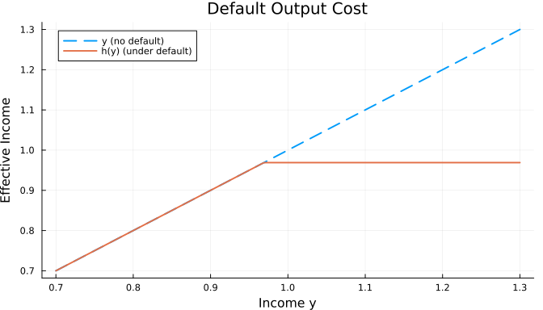

```julia
y_fine = LinRange(0.7, 1.3, 200)
plot(y_fine, y_fine, linewidth=2, linestyle=:dash, label="y (no default)",
     legend=:topleft, size=(700, 400))
plot!(y_fine, h.(y_fine, m.ŷ), linewidth=2, label="h(y) (under default)")
xlabel!("Income y")
ylabel!("Effective Income")
title!("Default Output Cost")
```

- Default is costlier when income is **high** — the government loses more output

# Solving the Model

## The Algorithm

### Overview

1. **Initialize** value functions $V^R$, $V^D$ and bond prices $q$
2. **Iterate**:
   1. Given $q$, update the government’s value functions and policies
   2. Given the default policy, update bond prices $q$
3. **Repeat** until both $V$ and $q$ converge

**Two Nested Fixed Points**

Unlike KP (where we only iterated on $V$), here we iterate on **both** $V$ and $q$. The bond price depends on future default decisions, which depend on the bond price.

### Interpolation in Sovereign Default

- In the KP lecture we introduced **linear interpolation** to handle continuous capital $k$
- Here we reuse the same tool — but with a twist
- In KP, the objective was **concave** in $k'$, so gradient-based optimization found the global optimum reliably
- Here, the endogenous bond price $q(b', y)$ creates **kinks** in the objective — it is not globally concave
- We use **grid search** over a fine grid (251 pts) while storing value functions on a sparse grid (101 pts) — simple, robust, and requires no concavity

**Where Interpolation Helps**

We store $V$ and $q$ on a **sparse grid** (101 points) and build `linear_interpolation` per income state. In the Bellman operator, we search over a **fine grid** (251 points), evaluating interpolated $V$ and $q$. This separates approximation accuracy from optimization accuracy. `V_itp[iy](0.0)` cleanly evaluates $V(0, y')$ for the default value.

### Taste Shocks: Connecting to Rust

- In the Rust lecture, we added **Type I Extreme Value** shocks to the keep/replace decision
- The same idea applies here: the government’s repay/default decision is perturbed by taste shocks
- **Without taste shocks**: $V(b, y) = \max\{V^R(b, y), \; V^D(y)\}$ — sharp cutoff
- **With taste shocks** (scale $\tau$):

$$V(b, y) = \tau \, \log\!\left[\exp\!\left(\frac{V^R}{\tau}\right) + \exp\!\left(\frac{V^D}{\tau}\right)\right]$$

- Default probability becomes a **smooth logistic** (just like Rust’s replacement probability):

$$\delta(b, y) = \frac{1}{1 + \exp\!\left(\frac{V^R(b, y) - V^D(y)}{\tau}\right)}$$

**The Role of $\tau$**

As $\tau \to 0$, we recover the original hard-max model. We set $\tau = 0.001$ as our baseline: this is close to the hard-max model while still providing a smooth default probability for numerical stability. The parameter $\tau$ plays the same role as the implicit scale $= 1$ in the Rust lecture.

### `smooth_max` and `default_prob`

- Two helper functions, using the **log-sum-exp trick** from the Rust lecture:

```julia
function smooth_max(v1, v2, τ)
    vmax = max(v1, v2)
    return vmax + τ * log(exp((v1 - vmax) / τ) + exp((v2 - vmax) / τ))
end

function default_prob(VR, VD, τ)
    return 1.0 / (1.0 + exp((VR - VD) / τ))
end
```

```
default_prob (generic function with 1 method)
```

- `smooth_max`: numerically stable log-sum-exp (subtracts the max before exponentiating)
- `default_prob`: logistic sigmoid — $P(\text{default}) = \frac{1}{1 + e^{(V^R - V^D)/\tau}}$

### Step 1: The Value of Default

- For each income state $y_j$, the value of default is:

$$V^D(y_j) = u(h(y_j)) + \beta \sum_{j'} P_{j,j'}\left[\lambda \, V(0, y_{j'}) + (1-\lambda) \, V^D(y_{j'})\right]$$

- The government consumes $h(y_j)$ today (with output cost)
- Next period: regains market access with probability $\lambda$ (enters with zero debt), otherwise stays in autarky

### Step 2: The Value of Repayment

- For each $(b_i, y_j)$, find the optimal new debt $b'$:

$$V^R(b_i, y_j) = \max_{b'} \left\{ u(y_j + b_i - q(b', y_j) \cdot b') + \beta \sum_{j'} P_{j,j'} V(b', y_{j'}) \right\}$$

- Search over the bond grid with interpolated $V$ and $q$ to find the best $b'$
- Consumption: $c = y_j + b_i - q(b', y_j) \cdot b'$

### Step 3: Update Bond Prices

- Compute the **smooth** default probability for each $(b', y)$ using the logistic:

$$\delta(b', y_j) = \sum_{j'} P_{j,j'} \cdot \frac{1}{1 + \exp\!\left(\frac{V^R(b', y_{j'}) - V^D(y_{j'})}{\tau}\right)}$$

- Update the bond price:

$$q(b', y_j) = \frac{1 - \delta(b', y_j)}{1 + r}$$

## Julia Implementation

### `optimal_default`: Pseudocode

- The core building block for **default**: given income index `iy`, the current value function, and VD, compute the value of defaulting today

```julia
function optimal_default(m, iy, V_itp, VD)
    # Consume h(y) (income with output cost)
    # Continuation: regain access (V(0, y')) with prob λ, stay in autarky (VD(y')) otherwise
    # Return the value of default
end
```

### `optimal_default`: Full Function

```julia
function optimal_default(m, iy, V_itp, VD)
    (; β, σ, λ, ŷ, N_y, y_grid, P_y) = m
    y = y_grid[iy]
    c_def = h(y, ŷ)                                        # income under default
    EV_def = sum(P_y[iy, iy2] * (λ * V_itp[iy2](0.0) +    # regain access at b=0
                 (1 - λ) * VD[iy2]) for iy2 in 1:N_y)      # or stay in autarky
    return u(c_def, σ) + β * EV_def
end
```

```
optimal_default (generic function with 1 method)
```

- `V_itp[iy2](0.0)` evaluates the continuation value at **zero debt** using interpolation — no need to find a grid index
- The government consumes $h(y)$ today and hopes to regain market access with probability $\lambda$

### A Simple `find_max` Helper

- Before writing `optimal_repayment`, let’s build a tiny utility: **grid search** over a vector to maximize a function

```julia
function find_max(f, grid)
    best_val = -Inf
    best_x   = grid[1]
    for x in grid
        val = f(x)
        if val > best_val
            best_val = val
            best_x   = x
        end
    end
    return (val = best_val, x = best_x)
end
```

```
find_max (generic function with 1 method)
```

- Evaluates `f` at every point in `grid` and returns the best `(val, x)`
- Simple, transparent, no external packages needed
- We search over the **fine grid** (`b_grid_fine`, 251 points) for accuracy, while storing values on the **sparse grid** (`b_grid`, 101 points)

### `optimal_repayment`: Pseudocode

- The core building block for **repayment**: given current debt $b$, income index `iy`, and interpolated $V$ and $q$, find the optimal new borrowing $b'$

```julia
function optimal_repayment(m, b, iy, V_itp, q_itp)
    # Define payoff(b'): flow utility + continuation value
    #   Consumption: c = y + b - q(b', y) × b'
    #   Continuation: E[V(b', y')] using interpolation
    # Search over fine grid using find_max
    # Return value and optimal b' as named tuple
end
```

### `optimal_repayment`: Full Function

```julia
function optimal_repayment(m, b, iy, V_itp, q_itp)
    (; β, σ, N_y, y_grid, P_y, b_grid_fine) = m
    y = y_grid[iy]
    function payoff(bp)
        c = y + b - q_itp[iy](bp) * bp
        c <= 0 && return -Inf
        EV = sum(P_y[iy, iy2] * V_itp[iy2](bp) for iy2 in 1:N_y)
        return u(c, σ) + β * EV
    end
    result = find_max(payoff, b_grid_fine)
    return (V = result.val, bp = result.x)
end
```

```
optimal_repayment (generic function with 1 method)
```

- `payoff(bp)` computes the **flow utility + discounted continuation** for any candidate $b'$
- `find_max` searches the **fine grid** (251 points) — more resolution than the sparse grid where we store $V$
- Returns a named tuple `(V, bp)` — the optimal value and borrowing level

### The Bellman Operator

- Now the Bellman operator simply **calls** our two building blocks and assembles the results:

```julia
function bellman_operator(m, V, VR, VD, q)
    # Build interpolants for V and q (once per iteration)
    # Call optimal_default for each income state
    # Call optimal_repayment for each (b, y) state
    # Return updated value functions and policies
end
```

### The Bellman Operator

```julia
function bellman_operator(m, V, VR, VD, q)
    (; N_y, N_b, b_grid) = m
    VR_new = similar(VR)
    VD_new = similar(VD)
    bp_policy = zeros(N_b, N_y)
    V_itp = [linear_interpolation(b_grid, V[:, iy]) for iy in 1:N_y]
    q_itp = [linear_interpolation(b_grid, q[:, iy]) for iy in 1:N_y]
    for iy in 1:N_y
        VD_new[iy] = optimal_default(m, iy, V_itp, VD)
    end
    for iy in 1:N_y
        for ib in 1:N_b
            result = optimal_repayment(m, b_grid[ib], iy, V_itp, q_itp)
            VR_new[ib, iy] = result.V
            bp_policy[ib, iy] = result.bp
        end
    end
    return VR_new, VD_new, bp_policy
end
```

```
bellman_operator (generic function with 1 method)
```

- `V_itp` and `q_itp` are built **once per iteration** (not once per state) for efficiency
- The Bellman operator is now clean and readable — each piece of logic lives in its own function

### The Bond Price Update

```julia
function update_bond_price(m, VR, VD)
    # For each (b', y), compute smooth default probability next period
    # Bond price = (1 - default_prob) / (1 + r)
    # Return updated q matrix
end
```

### The Bond Price Update

```julia
function update_bond_price(m, VR, VD)
    (; r, τ, N_y, N_b, P_y) = m
    q_new = zeros(N_b, N_y)
    for iy in 1:N_y
        for ibp in 1:N_b
            δ = sum(P_y[iy, iy2] * default_prob(VR[ibp, iy2], VD[iy2], τ)
                    for iy2 in 1:N_y)
            q_new[ibp, iy] = (1 - δ) / (1 + r)
        end
    end
    return q_new
end
```

```
update_bond_price (generic function with 1 method)
```

- `default_prob(VR, VD, τ)` returns the **smooth** logistic probability — no sharp 0/1 discontinuity
- This is the key benefit of taste shocks: bond prices vary **continuously** with debt and income

### The Full Solver

```julia
function solveSovDefault(m; tol=1e-6, maxiter=1500, verbose=true, α=0.5)
    # Initialize value functions and bond prices
    # Iterate: Bellman update + damped bond price update
    # V uses smooth_max (log-sum-exp with τ)
    # q updated with mixing: q = α·q_new + (1-α)·q_old (prevents oscillation)
    # Build interpolated policies for simulation
    # Return solution tuple with smooth default probabilities
end
```

### The Full Solver

```julia
function solveSovDefault(m; tol=1e-6, maxiter=1500, verbose=true, α=0.5)
    (; N_b, N_y, r, τ, b_grid) = m
    VR = zeros(N_b, N_y)
    VD = zeros(N_y)
    V = zeros(N_b, N_y)
    q = fill(1 / (1 + r), N_b, N_y)            # initial guess: risk-free price
    bp_policy = zeros(N_b, N_y)
    for iter in 1:maxiter
        VR_new, VD_new, bp_policy = bellman_operator(m, V, VR, VD, q)
        V_new = [smooth_max(VR_new[ib, iy], VD_new[iy], τ)
                 for ib in 1:N_b, iy in 1:N_y]
        q_lenders = update_bond_price(m, VR_new, VD_new)
        q_new = α .* q_lenders .+ (1 - α) .* q      # damped update
        dist_V = maximum(abs.(V_new - V))
        dist_q = maximum(abs.(q_new - q))
        if max(dist_V, dist_q) < tol
            verbose && println("Converged in $iter iterations (V: $(round(dist_V, sigdigits=3)), q: $(round(dist_q, sigdigits=3)))")
            VR = VR_new; VD = VD_new; V = V_new; q = q_new
            break
        end
        VR = VR_new;  VD = VD_new;  V = V_new;  q = q_new
        if verbose && iter % 25 == 0
            println("  iter $iter: dist_V = $(round(dist_V, sigdigits=3)), dist_q = $(round(dist_q, sigdigits=3))")
        end
        if iter == maxiter
            println("WARNING: did not converge after $maxiter iterations")
        end
    end
    def_prob = [default_prob(VR[ib, iy], VD[iy], τ) for ib in 1:N_b, iy in 1:N_y]
    VR_itp = [linear_interpolation(b_grid, VR[:, iy]) for iy in 1:N_y]
    bp_itp = [linear_interpolation(b_grid, bp_policy[:, iy]) for iy in 1:N_y]
    q_itp  = [linear_interpolation(b_grid, q[:, iy]) for iy in 1:N_y]
    return (V=V, VR=VR, VD=VD, q=q, bp=bp_policy, def_prob=def_prob,
            VR_itp=VR_itp, bp_itp=bp_itp, q_itp=q_itp)
end
```

```
solveSovDefault (generic function with 1 method)
```

- The **damping parameter** $\alpha = 0.5$ mixes new and old bond prices: $q \leftarrow \alpha \, q^{\text{new}} + (1-\alpha) \, q^{\text{old}}$
- With small $\tau$, default probabilities are nearly 0/1, so $q$ can jump dramatically between iterations
- Damping prevents oscillation and ensures convergence

**Why Damping?**

The bond price $q$ depends on future default, which depends on $q$ itself. With near-hard-max taste shocks ($\tau = 0.001$), small changes in $V$ near the default boundary cause large swings in $q$. Mixing old and new prices ($\alpha = 0.5$) smooths this feedback loop.

## Calibration

### Calibration Strategy

- Following Arellano (2008), we calibrate the model to **quarterly Argentine data**
- Parameters are either set **externally** (from data / standard values) or calibrated **internally** to match moments

[output not shown]

### Calibrating $\beta$

**Why $\beta < 1$?**

### Running the Solver

[output not shown]

```julia
m = setup!(SovDefaultModel())
sol = solveSovDefault(m)
println("Model: β = $(m.β), τ = $(m.τ)")
```

```
  iter 25: dist_V = 0.683, dist_q = 0.0158
  iter 50: dist_V = 0.384, dist_q = 8.46e-5
  iter 75: dist_V = 0.228, dist_q = 3.94e-6
  iter 100: dist_V = 0.137, dist_q = 1.81e-7
  iter 125: dist_V = 0.0825, dist_q = 8.17e-9
  iter 150: dist_V = 0.0498, dist_q = 3.7e-10
  iter 175: dist_V = 0.03, dist_q = 1.69e-11
  iter 200: dist_V = 0.0181, dist_q = 9.18e-13
  iter 225: dist_V = 0.0109, dist_q = 2.6e-13
  iter 250: dist_V = 0.0066, dist_q = 3.82e-13
  iter 275: dist_V = 0.00398, dist_q = 6.5e-13
  iter 300: dist_V = 0.0024, dist_q = 1.54e-12
  iter 325: dist_V = 0.00145, dist_q = 1.29e-12
  iter 350: dist_V = 0.000876, dist_q = 3.84e-13
  iter 375: dist_V = 0.000528, dist_q = 1.05e-12
  iter 400: dist_V = 0.000319, dist_q = 4.18e-13
  iter 425: dist_V = 0.000192, dist_q = 6.33e-13
  iter 450: dist_V = 0.000116, dist_q = 3.05e-13
  iter 475: dist_V = 7.01e-5, dist_q = 1.22e-12
  iter 500: dist_V = 4.23e-5, dist_q = 3.82e-13
  iter 525: dist_V = 2.55e-5, dist_q = 8.79e-13
  iter 550: dist_V = 1.54e-5, dist_q = 1.75e-12
  iter 575: dist_V = 9.29e-6, dist_q = 1.17e-12
  iter 600: dist_V = 5.61e-6, dist_q = 4.14e-13
  iter 625: dist_V = 3.38e-6, dist_q = 4.26e-13
  iter 650: dist_V = 2.04e-6, dist_q = 6.34e-13
  iter 675: dist_V = 1.23e-6, dist_q = 4.68e-13
Converged in 686 iterations (V: 9.87e-7, q: 6.19e-13)
Model: β = 0.98, τ = 0.001
```

**Patience**

This takes longer than the KP model because we iterate on **both** value functions and bond prices. Each iteration optimizes over $b'$ for every $(b, y)$ state — $N_b \times N_y$ evaluations per iteration.

## Results

### The Value Function

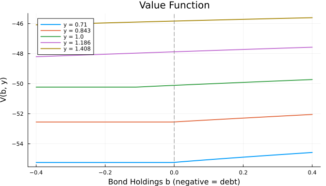

```julia
iy_set = round.(Int, LinRange(1, m.N_y, 5))
plot(legend=:topleft, size=(700, 400))
for iy in iy_set
    plot!(m.b_grid, sol.V[:, iy], linewidth=2,
          label="y = $(round(m.y_grid[iy], digits=3))")
end
xlabel!("Bond Holdings b (negative = debt)")
ylabel!("V(b, y)")
title!("Value Function")
vline!([0.0], color=:gray, linestyle=:dash, label="")
```

- Higher income → higher value at every debt level
- Value is increasing in $b$ (less debt = better)

### Breaking Down the Repayment Objective

- The government’s repayment problem chooses new debt $b'$ to solve:

$$V^R(b, y) = \max_{b'} \underbrace{\left\{ u\!\left(y + b - q(b', y) \cdot b'\right) + \beta \, \mathbb{E}\left[V(b', y') \mid y\right] \right\}}_{\text{obj}(b'; \, b, y)}$$

- Let’s fix income at the **median** and plot $\text{obj}(b')$ for various current debt levels $b$
- This reveals the **shape** of the optimization problem and when the government **prefers default**

### The Objective at Converged $V$ and $q$

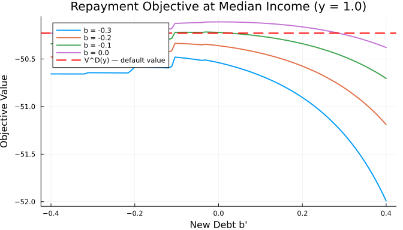

```julia
iy_mid = (m.N_y + 1) ÷ 2
y_mid = m.y_grid[iy_mid]
V_itp_plot = [linear_interpolation(m.b_grid, sol.V[:, iy]) for iy in 1:m.N_y]
q_itp_plot = [linear_interpolation(m.b_grid, sol.q[:, iy]) for iy in 1:m.N_y]

b_show = [-0.3, -0.2, -0.1, 0.0]
plot(legend=:topleft, size=(700, 400))
for bv in b_show
    obj = [let c = y_mid + bv - q_itp_plot[iy_mid](bp) * bp
           c > 0 ? u(c, m.σ) + m.β * sum(m.P_y[iy_mid, j] * V_itp_plot[j](bp)
                    for j in 1:m.N_y) : NaN
           end for bp in m.b_grid]
    plot!(m.b_grid, obj, linewidth=2, label="b = $bv")
end
hline!([sol.VD[iy_mid]], color=:red, linestyle=:dash, linewidth=2,
       label="V^D(y) — default value")
xlabel!("New Debt b'")
ylabel!("Objective Value")
title!("Repayment Objective at Median Income (y = $(round(y_mid, digits=3)))")
```

- Each curve peaks at the **optimal** $b'$ for that debt level
- The red dashed line is $V^D(y)$: if the best repayment value lies below it, the government defaults
- With more current debt ($b$ more negative), the objective shifts **down** and the feasible region narrows

### Decomposing Flow Utility vs. Continuation

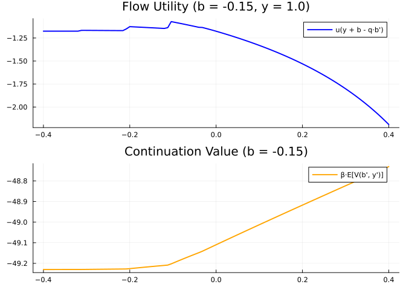

```julia
bv = -0.15                                      # moderate debt
flow = [let c = y_mid + bv - q_itp_plot[iy_mid](bp) * bp
        c > 0 ? u(c, m.σ) : NaN end for bp in m.b_grid]
cont = [m.β * sum(m.P_y[iy_mid, j] * V_itp_plot[j](bp)
        for j in 1:m.N_y) for bp in m.b_grid]
p1 = plot(m.b_grid, flow, linewidth=2, color=:blue,
          label="u(y + b - q·b')", legend=:topright, size=(700, 250),
          title="Flow Utility (b = $bv, y = $(round(y_mid, digits=3)))")
p2 = plot(m.b_grid, cont, linewidth=2, color=:orange,
          label="β·E[V(b', y')]", legend=:topright, size=(700, 250),
          title="Continuation Value (b = $bv)")
plot(p1, p2, layout=(2, 1), size=(700, 500))
```

- **Flow utility** peaks at moderate borrowing: past a point, more debt drives down $q$ faster than it raises revenue (the sovereign “Laffer curve”)
- **Continuation value** falls steadily with borrowing: more debt today $\to$ worse starting point tomorrow
- The **optimal** $b'$ balances today’s consumption against tomorrow’s debt burden

### Default Probability (Smooth)

```julia
heatmap(m.y_grid, m.b_grid, sol.def_prob,
        xlabel="Income y", ylabel="Bond Holdings b",
        title="Default Probability",
        color=:YlOrRd, clims=(0, 1), size=(700, 400))
```

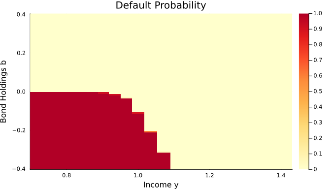

### Bond Price Schedule

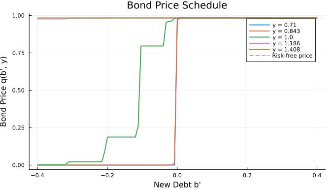

```julia
iy_set = round.(Int, LinRange(1, m.N_y, 5))
plot(legend=:topright, size=(700, 400))
for iy in iy_set
    plot!(m.b_grid, sol.q[:, iy], linewidth=2,
          label="y = $(round(m.y_grid[iy], digits=3))")
end
hline!([1 / (1 + m.r)], color=:gray, linestyle=:dash, label="Risk-free price")
xlabel!("New Debt b'")
ylabel!("Bond Price q(b', y)")
title!("Bond Price Schedule")
```

- Bond prices **fall** as the government borrows more — lenders demand compensation for higher default risk
- Higher income → higher bond prices (lower default risk)

### Sovereign Spreads

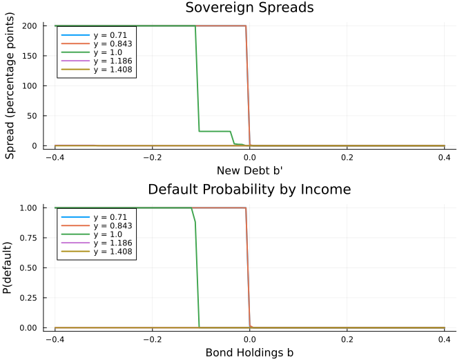

```julia
iy_set = round.(Int, LinRange(1, m.N_y, 5))
p1 = plot(legend=:topleft, size=(700, 300), title="Sovereign Spreads")
for iy in iy_set
    spread = (1 ./ max.(sol.q[:, iy], 1e-8)) .- (1 + m.r)
    spread = clamp.(spread, 0, 2.0)                        # cap at 200%
    plot!(p1, m.b_grid, 100 .* spread, linewidth=2,
          label="y = $(round(m.y_grid[iy], digits=3))")
end
xlabel!(p1, "New Debt b'")
ylabel!(p1, "Spread (percentage points)")

p2 = plot(legend=:topleft, size=(700, 300), title="Default Probability by Income")
for iy in iy_set
    plot!(p2, m.b_grid, sol.def_prob[:, iy], linewidth=2,
          label="y = $(round(m.y_grid[iy], digits=3))")
end
xlabel!(p2, "Bond Holdings b")
ylabel!(p2, "P(default)")

plot(p1, p2, layout=(2, 1), size=(700, 550))
```

### Borrowing Policy

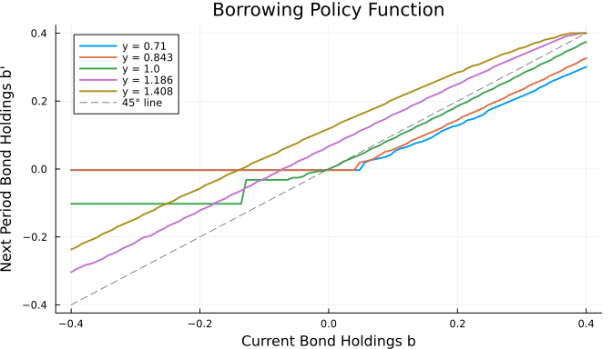

```julia
iy_set = round.(Int, LinRange(1, m.N_y, 5))
plot(legend=:topleft, size=(700, 400))
for iy in iy_set
    plot!(m.b_grid, sol.bp[:, iy], linewidth=2,
          label="y = $(round(m.y_grid[iy], digits=3))")
end
plot!(m.b_grid, m.b_grid, color=:gray, linestyle=:dash, label="45° line")
xlabel!("Current Bond Holdings b")
ylabel!("Next Period Bond Holdings b'")
title!("Borrowing Policy Function")
```

- Below the 45° line: the government is **accumulating debt** ($b' < b$)
- Above the 45° line: the government is **saving** or **reducing debt**

# Simulation

## Simulating the Economy

### The Simulation Function

```julia
function simulateSovDefault(m, sol, T; seed=42)
    # Initialize at zero debt and median income
    # Each period: compute smooth default probability, draw Bernoulli shock
    # If not in default: use interpolated policy bp_itp for borrowing
    # If in default: consume h(y), try to regain access
    # Return named tuple
end
```

### The Simulation Function

```julia
function simulateSovDefault(m, sol, T; seed=42)
    Random.seed!(seed)
    (; r, λ, τ, ŷ, σ, y_grid, P_y, b_grid, N_y) = m
    b_sim = zeros(T);  y_sim = zeros(T);  c_sim = zeros(T)
    spread_sim = zeros(T);  default_sim = zeros(Int, T)
    b = 0.0                                    # start at zero debt
    iy = (N_y + 1) ÷ 2                        # start at median income
    in_default = false
    for t in 1:T
        y = y_grid[iy]
        b_sim[t] = b;  y_sim[t] = y
        if in_default
            c_sim[t] = h(y, ŷ)
            default_sim[t] = 1
            spread_sim[t] = NaN
            in_default = rand() > λ           # try to regain access
            if !in_default;  b = 0.0;  end
        else
            # Stochastic default: Bernoulli draw (as in Rust simulation)
            δ_prob = default_prob(sol.VR_itp[iy](b), sol.VD[iy], τ)
            if rand() < δ_prob                  # draw default shock
                c_sim[t] = h(y, ŷ)
                default_sim[t] = 1;  in_default = true
                spread_sim[t] = NaN
            else                               # government repays
                bp = clamp(sol.bp_itp[iy](b), b_grid[1], b_grid[end])
                qval = sol.q_itp[iy](bp)
                c_sim[t] = y + b - qval * bp
                spread_sim[t] = max((1 / max(qval, 1e-8)) - (1 + r), 0.0)
                b = bp
            end
        end
        iy = rand(Categorical(P_y[iy, :]))
    end
    return (t=1:T, b=b_sim, y=y_sim, c=c_sim, spread=spread_sim, default=default_sim)
end
```

```
simulateSovDefault (generic function with 1 method)
```

### Running the Simulation

```julia
sim = simulateSovDefault(m, sol, 500)
println("Default rate: ", round(mean(sim.default), digits=3))
```

```
Default rate: 0.08
```

### Debt and Income Dynamics

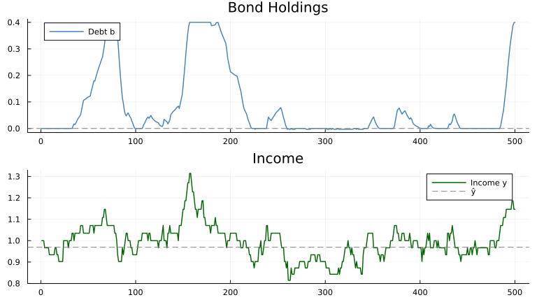

```julia
p1 = plot(sim.b, linewidth=1.5, color=:steelblue, label="Debt b",
          title="Bond Holdings", size=(800, 200))
hline!(p1, [0.0], color=:gray, linestyle=:dash, label="")
p2 = plot(sim.y, linewidth=1.5, color=:darkgreen, label="Income y",
          title="Income", size=(800, 200))
hline!(p2, [m.ŷ], color=:gray, linestyle=:dash, label="ŷ")
plot(p1, p2, layout=(2, 1), size=(800, 450))
```

### Consumption and Spreads

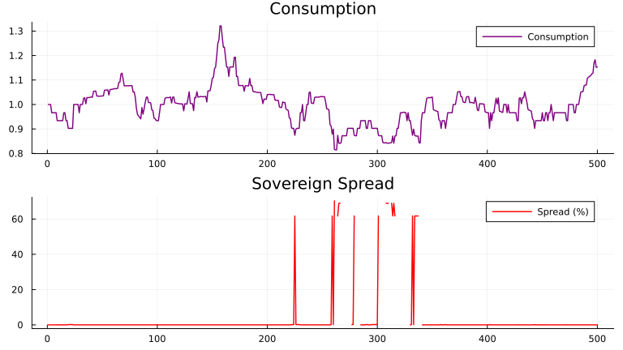

```julia
p1 = plot(sim.c, linewidth=1.5, color=:purple, label="Consumption",
          title="Consumption", size=(800, 200))
p2 = plot(100 .* sim.spread, linewidth=1.5, color=:red, label="Spread (%)",
          title="Sovereign Spread", size=(800, 200))
plot(p1, p2, layout=(2, 1), size=(800, 450))
```

- Consumption drops sharply at default (output cost)
- Spreads spike before default events — lenders anticipate the crisis

### Default Episodes

[output not shown]

## Comparative Statics

### Effect of Risk Aversion ($\sigma$)

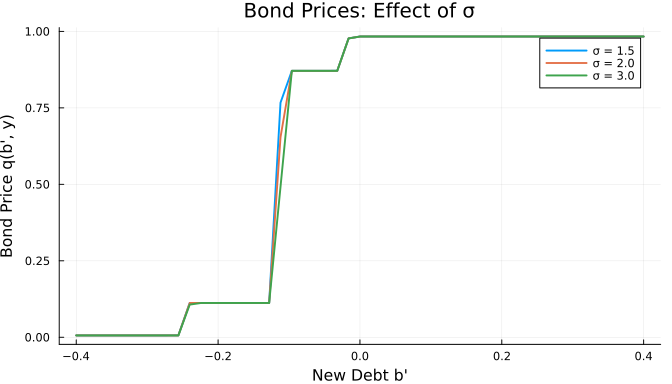

```julia
plot(legend=:topright, size=(700, 400), title="Bond Prices: Effect of σ")
for σ_val in [1.5, 2.0, 3.0]
    m_trial = setup!(SovDefaultModel(β=0.980, σ=σ_val, N_b=51, N_b_fine=101, N_y=11))
    sol_trial = solveSovDefault(m_trial, verbose=false)
    iy_mid = (m_trial.N_y + 1) ÷ 2
    plot!(m_trial.b_grid, sol_trial.q[:, iy_mid], linewidth=2, label="σ = $σ_val")
end
xlabel!("New Debt b'")
ylabel!("Bond Price q(b', y)")
```

- Higher risk aversion → government values consumption smoothing more → different borrowing patterns

### Effect of Re-entry Probability ($\lambda$)

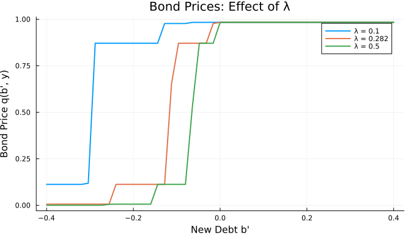

```julia
plot(legend=:topright, size=(700, 400), title="Bond Prices: Effect of λ")
for λ_val in [0.1, 0.282, 0.5]
    m_trial = setup!(SovDefaultModel(β=0.980, λ=λ_val, N_b=51, N_b_fine=101, N_y=11))
    sol_trial = solveSovDefault(m_trial, verbose=false)
    iy_mid = (m_trial.N_y + 1) ÷ 2
    plot!(m_trial.b_grid, sol_trial.q[:, iy_mid], linewidth=2, label="λ = $λ_val")
end
xlabel!("New Debt b'")
ylabel!("Bond Price q(b', y)")
```

- Higher $\lambda$ → shorter exclusion from credit → default is less costly → more default → lower bond prices

### Effect of Taste Shock Scale ($\tau$)

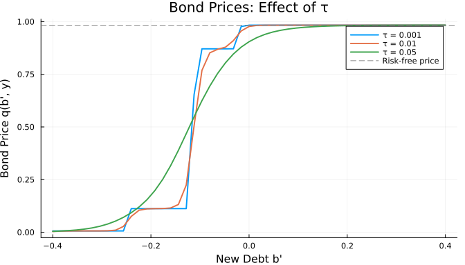

```julia
plot(legend=:topright, size=(700, 400), title="Bond Prices: Effect of τ")
for τ_val in [0.001, 0.01, 0.05]
    m_trial = setup!(SovDefaultModel(β=0.980, τ=τ_val, N_b=51, N_b_fine=101, N_y=11))
    sol_trial = solveSovDefault(m_trial, verbose=false)
    iy_mid = (m_trial.N_y + 1) ÷ 2
    plot!(m_trial.b_grid, sol_trial.q[:, iy_mid], linewidth=2, label="τ = $τ_val")
end
hline!([1 / (1 + m.r)], color=:gray, linestyle=:dash, label="Risk-free price")
xlabel!("New Debt b'")
ylabel!("Bond Price q(b', y)")
```

- $\tau = 0.001$: our baseline — very close to the hard-max model, sharp default boundary
- $\tau = 0.01$: light smoothing — slightly blurred default boundary
- $\tau = 0.05$: heavier smoothing — default boundary blurs, useful when convergence is difficult

# Summary

### Key Takeaways

**Concepts**

- Sovereign default as a dynamic discrete choice
- Eaton-Gersovitz / Arellano model
- Endogenous bond price schedule and credit limits
- Default region: high debt, low income
- Sovereign spreads and the feedback loop
- Taste shocks: log-sum-exp and logistic probabilities (from Rust)
- Output costs and exclusion from credit markets

**Julia Tools**

- Rouwenhorst discretization (reused from KP)
- Mutable structs with `setup!` and `@kwdef`
- Two-dimensional value function iteration
- `smooth_max` and `default_prob` (log-sum-exp + logistic, from Rust)
- Linear interpolation for simulation policies (reused from KP)
- Bernoulli draws for stochastic default (as in Rust simulation)

**Remember**

The sovereign default model shows why countries face **higher borrowing costs** when they carry more debt or have weaker economies. The key mechanism is that bond prices are set by risk-neutral lenders who anticipate the government’s future default decisions — creating a **feedback loop** between borrowing costs and default incentives. Unlike domestic models, there is **no enforcement mechanism** — the government repays only because default is costly (output loss + market exclusion).